# 3-avl-trees slides

#### Deletion

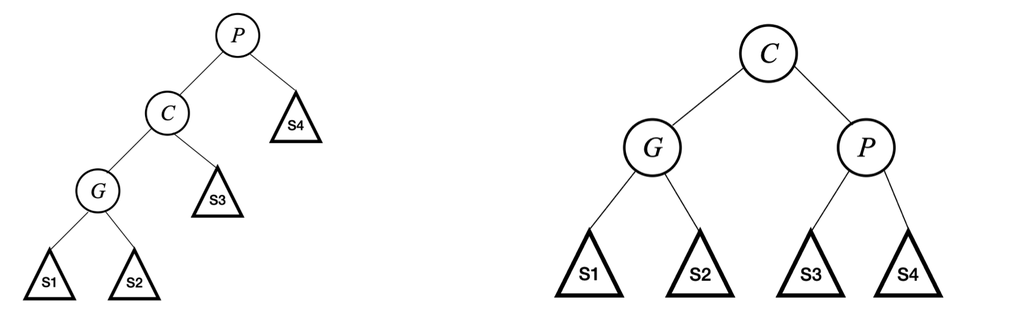

- **(before) $P$ is at $(h+2)$**
- **(now) $C$ is at $(h+1)$ or $(h+2)$**
- Height of this subtree (previously rooted at $P$ and now at $C$) may have gone down!
- So...what?

#### Deletion

##### Case 2

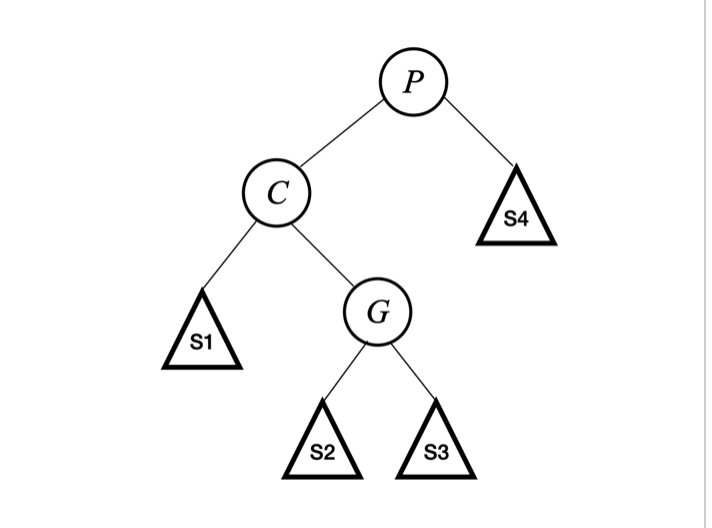

- Deletion happens in $S4$
  - Its height changes from $h$ to $(h-1)$
- Since $P$ was balanced before and is unbalanced now,
  - $P\ $ is at $(h+2)$
  - Height of $C\ $ is $(h+1)$
  - Therefore $G\ $ is at $h$
  - $S1\ $ is at $(h-1)$
    - if it was at $h$, we would go back to case 1
  - $S2\ $ and $S3\ $ at $(h-1)\ $ or $(h-2)$
    - at least one of them is at $(h-1)$.

#### Deletion

Double Rotation

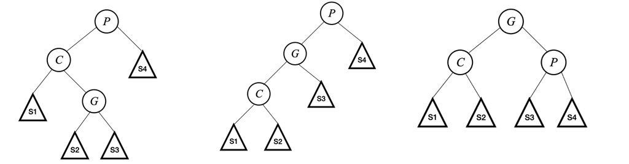

#### Deletion

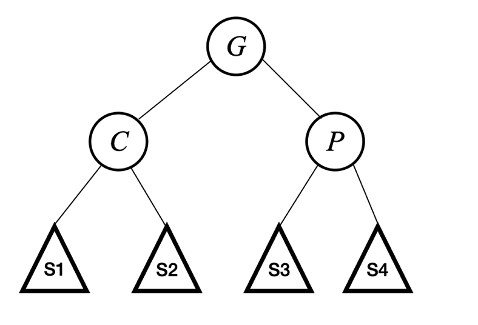

### Observation

##### We may need go any further up in the tree for rebalancing.

##### $\because$ The height of the modified subtree may have reduced. (case 1)

##### $\because$ The height of the modified subtree does reduce. (case 2)

#### Time Complexity

- Insertion:
  - $O(\log n)\ $ time for adding the new leaf.
  - $O(1)\ $ time for the rotation
  - Total: $O(\log n)$
- Deletion:
  - $O(\log n)\ $ time for deleting the node (3 cases).
  - $O(1)\ $ time for the rotation, but may need at most $\log n$ rotations.
  - Total: $O(\log n)$